# SOC-GA 2332 Intro to Stats Lab 2 Exercise Solution

Wenhao Jiang

9/15/2023

```r
knitr::opts_chunk$set(echo = TRUE)

# Load package to environment
library(tidyverse)
library(gridExtra)
library(kableExtra)

# Load csv files
gapminder <- read.csv("data/gapminder.csv")
```

### Part 1 Exercise

1. In the `gapminder` data, which are the top 5 countries in Europe in terms of their GDP per Capital in 2002? Use `dyplr` functions to create a table for your result.

```r
gapminder %>%
  filter(continent == "Europe" & year == 2002) %>%
  arrange(desc(gdpPercap)) %>%
  slice(1:5)
```

| country | continent | year | lifeExp | pop | gdpPercap |
| --- | --- | --- | --- | --- | --- |
| Norway | Europe | 2002 | 79.050 | 4535591 | 44683.98 |
| Switzerland | Europe | 2002 | 80.620 | 7361757 | 34480.96 |
| Ireland | Europe | 2002 | 77.783 | 3879155 | 34077.05 |
| Netherlands | Europe | 2002 | 78.530 | 16122830 | 33724.76 |
| Austria | Europe | 2002 | 78.980 | 8148312 | 32417.61 |

2. Using the `gapminder` data, generate a table summarising the mean, median, and standard deviation of life expadency in Europe and Africa in 2002.

```r
gapminder %>%
  filter(continent %in% c("Europe", "Africa") & year == 2002) %>%
  group_by(continent) %>%
  summarise(mean_life = mean(lifeExp),
            median_life = median(lifeExp),
            sd_life = sd(lifeExp))
```

| continent | mean_life | median_life | sd_life |
| --- | --- | --- | --- |
| Africa | 53.32523 | 51.2355 | 9.586496 |
| Europe | 76.70060 | 77.5365 | 2.922180 |

3. Replicate this plot below using the `gapminder` data and `ggplot2`?

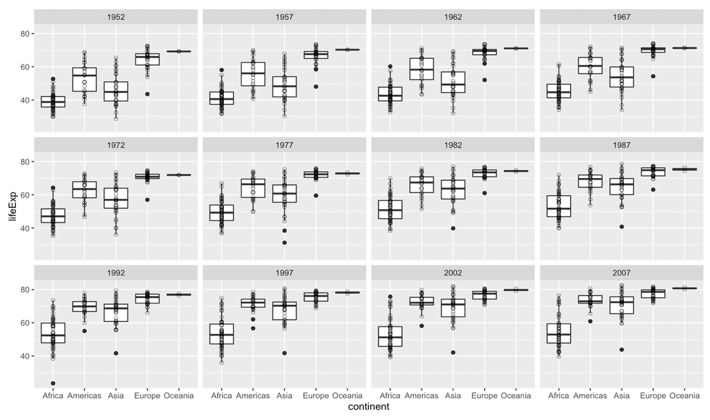

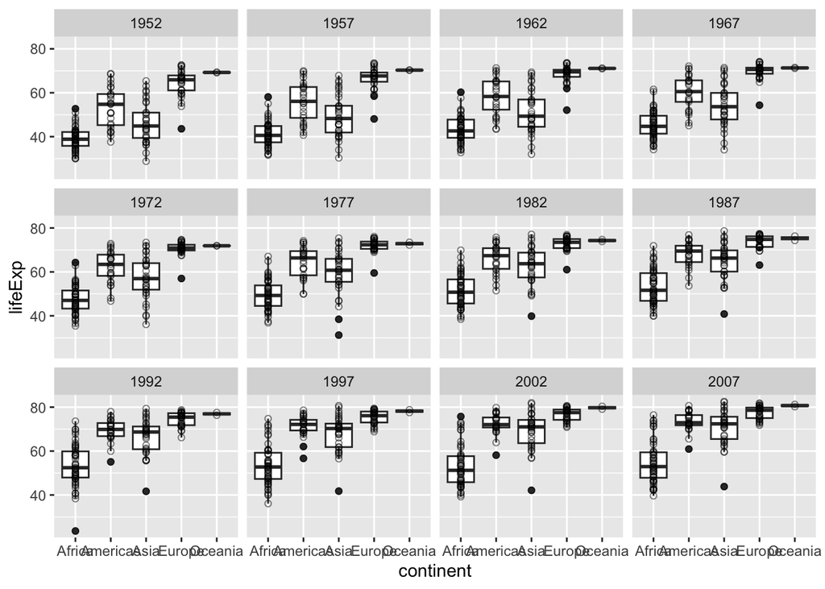

```r
gapminder %>%
  ggplot(aes(x = continent, y = lifeExp)) +
  geom_boxplot() +
  geom_point(alpha = 0.5, shape = 1) +
  facet_wrap(vars(year))
```

### Part 2 Exercise

Create a sampling distribution of the sample mean  
(1) Create a virtual population that follows a normal distribution of mean = 0 and variance = 1, with 10,000 observations. *Hint*: use `rnorm()`.  
(2) Use this population and a `for`-loop, get a sampling distribution of the sample mean by sampling 100 observations from the population for 1,000 times.  
(3) Plot a histogram of your sampling distribution of the sample mean. You can add lines for mean and SD as demonstrated in the figure above.

*Note:* Use the `set.seed()` function every time you perform a random process. That is, add the `set.seed()` function before every part of your code that involves a random process and run the `set.seed()` function together with that code for every run.

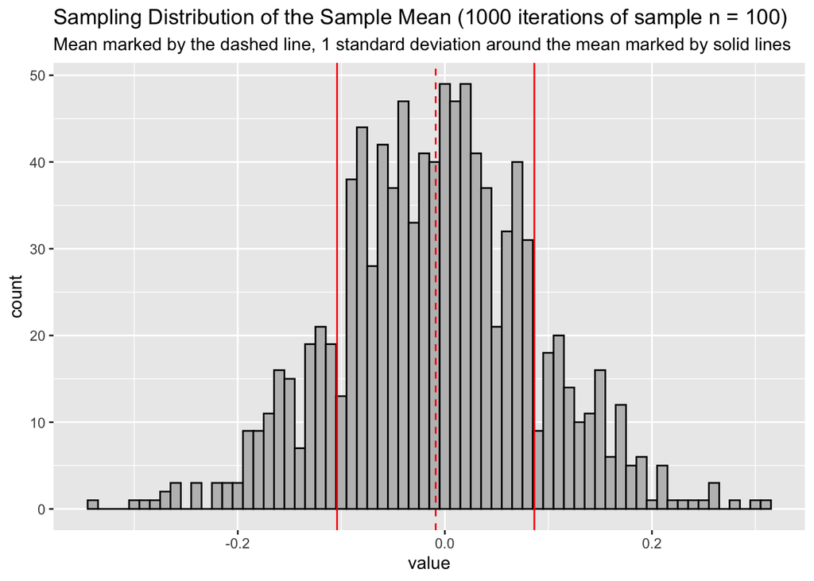

```r
set.seed(2023)

# generate population df
pop_norm <- rnorm(n = 10000, mean = 0, sd = 1)

# create a "container" object to save the mean
mean_vec <- rep(NA, 1000)

# repeatly sample from the pop df and save the mean
for (i in 1:1000){

  sample <- pop_norm %>% sample(size = 100, replace = FALSE)

  mean_vec[i] <- mean(sample)

}



# Mean and SD of the sampling distribution
mean = mean(mean_vec)
sd_pos = mean + sd(mean_vec)
sd_neg = mean - sd(mean_vec)


# Plot
mean_vec %>%
  as_tibble() %>%
  ggplot(aes(value)) +
  geom_histogram(binwidth = 0.01, fill = "grey", color = "black") +
  geom_vline(aes(xintercept = sd_neg), color = "red") +
  geom_vline(aes(xintercept = mean), color = "red", linetype = "dashed") +
  geom_vline(aes(xintercept = sd_pos), color = "red") +
  labs(title = "Sampling Distribution of the Sample Mean (1000 iterations of sample n = 100)",
       subtitle = "Mean marked by the dashed line, 1 standard deviation around the mean marked by solid lines")
```